# Analysis of Subfamili

Robin von Allmen

18 3 2021

## Preparing Data

Path to Data: “~/GitHub/Ichneumonidae/R-Scripts/Determine Higher-Crouping”

Data contains 234 specimens from Ophioniformes/Ichneumoniformes/Pimpliformes. However, we will only select certain subfamilies (Banchinae/Ophioninae/Pimplinae/Ichneumoninae/Phygadeuontinae (here still marked as Gelinae from Townes 1969)).

!!! This is the first time these subfamilies have been compared with geometric morphometrics by forewing venation!!!

After Data-Aquisation we superimpose the Data with the function gpagen().

## PCA Analysis

A PCA was done with the subfamilies Pimplinae, Gelinae, Ophioninae, Ichneumoninae and Banichnae.The ophioninae are seperated from the rest of the subfamilies quite strongly.The pimplinae are also partially seperated. They partly overlap with Gelinae and Ichneumoninae. The Gelinae overlap mostly with Banchinae and partially with Pimplinae. Overall the subfamilies cluster mostly in groups. However, there are some outliers clustering within another group.

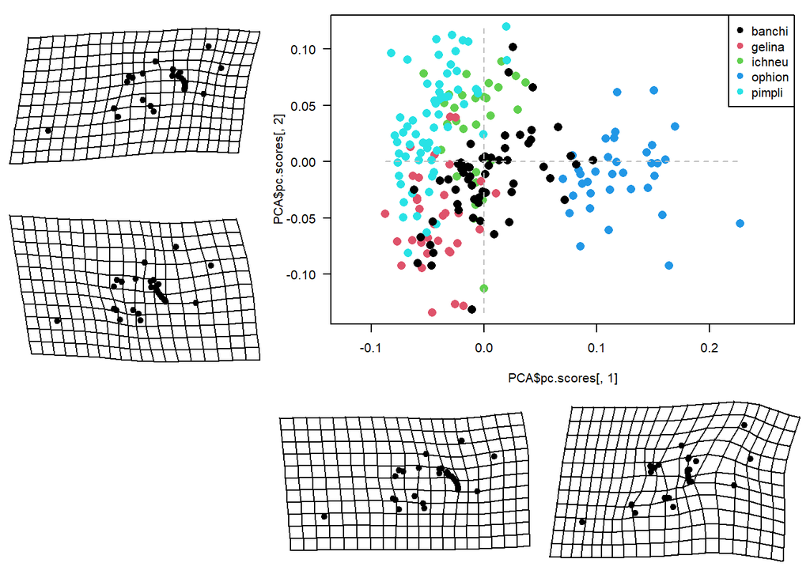

```r
PCA <-plotTangentSpace(pro_red$coords, groups=subfam1, legend=T)
```

## CVA

A CVA was done with the subfamilies Pimplinae, Gelinae, Ophioninae, Ichenumoninae and Banichnae.The Ophioninae seperate very strong from the rest of the subfamilies. The Gelinae are overlapping with the Ichneumininae. The Pimplinae and Banchinae are overlapping as well. The Pimplinae have a small overlap with the Ichneumoninae.Overall the subfamilies cluster mostly in groups. However, there are few outliers that cluster in another group. The 95% confidence ellipses show the probablity of the dots really being in the ellpipses. Here, the probabilty is 95%.

```r
#CVA
cva<- CVA(pro_red$coords, groups = subfam1, plot= T, rounds= 1000)
```

```
## singular Covariance matrix: General inverse is used. Threshold for zero eigenvalue is 1e-10
```

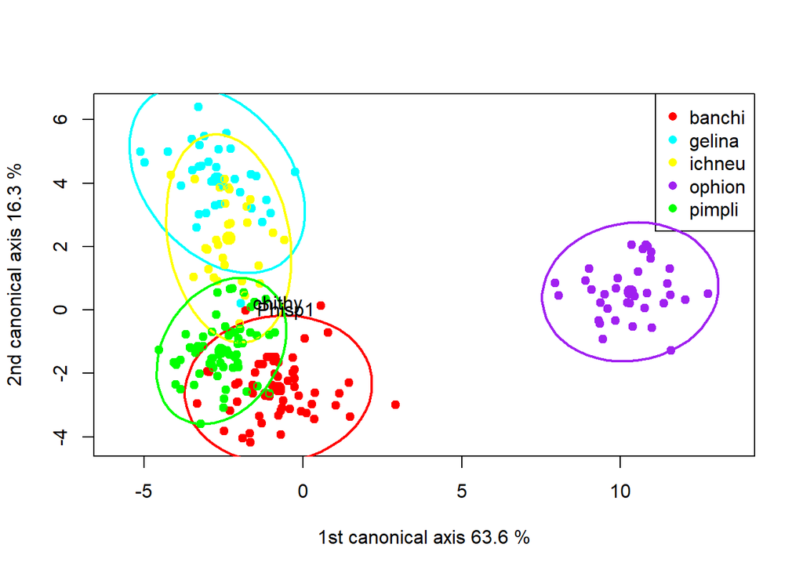

```r
my_colours <- c("red", "cyan", "yellow", "purple", "green")[subfam1]
# plot the CVA
plot(cva$CVscores, col=my_colours, pch=16,asp=1,
     xlab=paste("1st canonical axis", paste(round(cva$Var[1,2],1),"%")),
     ylab=paste("2nd canonical axis", paste(round(cva$Var[2,2],1),"%")))
legend("topright", legend=levels(subfam1), col = c("red", "cyan", "yellow", "purple", "green"), pch=16)

require(car)
for(ii in 1:length(levels(subfam1))){
    dataEllipse(cva$CVscores[subfam1==levels(subfam1)[ii],1],
    cva$CVscores[subfam1==levels(subfam1)[ii],2],
                    add=TRUE,levels=.95, col=c("red", "cyan", "yellow", "purple", "green")[ii])}

text(cva$CVscores[200,1], cva$CVscores[200,2], as.character(species1[200]), col="black", cex=1, pos=4)
text(cva$CVscores[49,1], cva$CVscores[49,2], as.character(species1[49]), col="black", cex=1, pos=4)
```

## Cluster Analysis

```r
data = data.frame(species1, subfam1, PCA$pc.scores[,1:25])

# Compute distances and hierarchical clustering

de <- dist(scale(data[c(3:27)]), method = "euclidean")

## Ward's minimum variance method

hd <- hclust(de, method = "ward.D2")

hd$labels = paste (subfam1,species1, sep = "_", collapse = NULL, recycle0 = FALSE)
# Convert hclust into a dendrogram and plot

hce <- as.dendrogram (hd)
```

## Dendrogramm

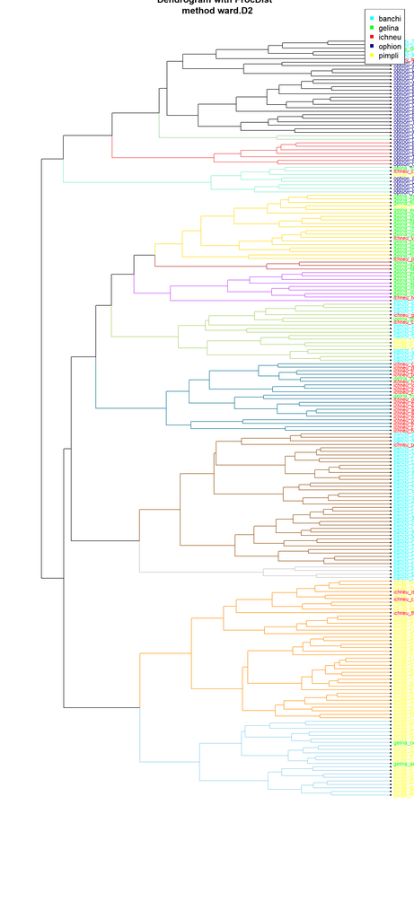

```r
require("dendextend") ## needs a dendrogram

par(mar= c(10,3,1,1))
Label <- hce%>%labels
my_colors1 = matrix( NA, dim(Proc_dist))
for(i in 1:length(row.names(Proc_dist))){
my_colors1[i] <- switch(substr(Label[i],1,6), "banchi" = "cyan", "pimpli" = "yellow", "gelina" = "green", "ophion" = "darkblue", "ichneu" = "red")
}
hce %>%
  set("labels_col", value =  my_colors1) %>%
  set("branches_k_color", value = c("skyblue", "darkorange", "grey","darkorange4","deepskyblue4",
                                    "darkolivegreen3","darkorchid1","firebrick","gold1","aquamarine2","brown2","darkseagreen3","black"),k = 13) %>%
  set("labels_cex", 0.7)  %>%
  set("leaves_pch", 19)  %>%
  set("nodes_cex", 0.4) %>%
  plot(axes=FALSE, main= "Dendrogram with ProcDist \n method ward.D2", horiz = TRUE)

# Add the colored bar
#colored_bars(colors = my_colors1, rowLabels = "subfam")
legend("topright", legend=levels(subfam1), col= c("cyan", "green", "red", "darkblue", "yellow"), pch=15)
```